# Assignmet4_1

Dipesh Poudel

10/5/2021

## Web Scrapping. Getting data from Table in a website

### Getting the Data from Website

```r
library(rvest)
library(dplyr)
wiki_link <- "https://en.wikipedia.org/wiki/COVID-19_pandemic_in_Nepal"
# Reading the whole website
wiki_page <- read_html(wiki_link)
# Getting only the tables from the whole website
tables <- wiki_page %>% html_table(fill = TRUE)
# Printing a sample table
print(tables[[2]])
```

```
## # A tibble: 16 × 2
##    `COVID-19 pandemic in Nepal`           `COVID-19 pandemic in Nepal`
##    <chr>                                  <chr>
##  1 Disease                                COVID-19
##  2 Virus strain                           SARS-CoV-2
##  3 Location                               Nepal
##  4 First outbreak                         Wuhan, Hubei, China
##  5 Index case                             Kathmandu, Bagmati Province
##  6 Arrival date                           9 January 2020(1 year, 8 months, 1 we…
##  7 Date                                   23 January 2020
##  8 Confirmed cases                        798,766[1] (updated 6 October 2021)
##  9 Active cases                           18,115 (1 October)[2]
## 10 Recovered                              766,696 (1 October)[2]
## 11 Deaths                                 11,180[1] (updated 6 October 2021)
## 12 Fatality rate                          1.4% (1 October)
## 13 Territories                            Active cases in  out of 77 districts
## 14 Vaccinations                           7,913,555[1] (total vaccinated)6,409,…
## 15 Government website                     Government website
## 16 COVID-19 Dashboard (MoHP) Nepal COVID… COVID-19 Dashboard (MoHP) Nepal COVID…
```

```r
# Getting the Required Table
covid_table <- wiki_page %>%html_nodes("table") %>% .[16] %>%html_table() %>% .[[1]]
print(head(covid_table))
```

```
## # A tibble: 6 × 14
##   Date   `Confirmed case… `Confirmed case… `Confirmed case… Recoveries Recoveries
##   <chr>  <chr>            <chr>            <chr>            <chr>      <chr>
## 1 Date   Total            New              Active           Total      New
## 2 23 Jan 1                +1               1                0          0
## 3 24 Jan 1                0                1                0          0
## 4 25 Jan 1                0                1                0          0
## 5 26 Jan 1                0                1                0          0
## 6 27 Jan 1                0                1                0          0
## # … with 8 more variables: Deaths <chr>, Deaths <chr>, RT-PCR tests <chr>,
## #   RT-PCR tests <chr>, TPR <chr>, RR <chr>, CFR <chr>, Ref. <chr>
```

### Getting the Structure of the dataframe

```r
str(covid_table)
```

```
## tibble [496 × 14] (S3: tbl_df/tbl/data.frame)
##  $ Date           : chr [1:496] "Date" "23 Jan" "24 Jan" "25 Jan" ...
##  $ Confirmed cases: chr [1:496] "Total" "1" "1" "1" ...
##  $ Confirmed cases: chr [1:496] "New" "+1" "0" "0" ...
##  $ Confirmed cases: chr [1:496] "Active" "1" "1" "1" ...
##  $ Recoveries     : chr [1:496] "Total" "0" "0" "0" ...
##  $ Recoveries     : chr [1:496] "New" "0" "0" "0" ...
##  $ Deaths         : chr [1:496] "Total" "0" "0" "0" ...
##  $ Deaths         : chr [1:496] "New" "0" "0" "0" ...
##  $ RT-PCR tests   : chr [1:496] "Total" "" "" "" ...
##  $ RT-PCR tests   : chr [1:496] "New" "" "" "" ...
##  $ TPR            : chr [1:496] "TPR" "" "" "" ...
##  $ RR             : chr [1:496] "RR" "0%" "0%" "0%" ...
##  $ CFR            : chr [1:496] "CFR" "0%" "0%" "0%" ...
##  $ Ref.           : chr [1:496] "Ref." "[169]" "" "" ...
```

As we can see all the variables (columns) have `char` data type and also the first row and second row are heading. We need to resolve this. This process of cleaning up data is called scrubbing or Tiding the data.

### Removing the first row and last column

```r
#Changing column names: Column Underscore Row 1
names(covid_table) = paste(names(covid_table), covid_table[1, ], sep = "_")
#Removing first row
covid_table = covid_table[-1, ]
#Removing last column
covid_table <- covid_table[,-14]
#Viewing the data
View(covid_table)
#Checking structure of the data
str(covid_table)
```

```
## tibble [495 × 13] (S3: tbl_df/tbl/data.frame)
##  $ Date_Date             : chr [1:495] "23 Jan" "24 Jan" "25 Jan" "26 Jan" ...
##  $ Confirmed cases_Total : chr [1:495] "1" "1" "1" "1" ...
##  $ Confirmed cases_New   : chr [1:495] "+1" "0" "0" "0" ...
##  $ Confirmed cases_Active: chr [1:495] "1" "1" "1" "1" ...
##  $ Recoveries_Total      : chr [1:495] "0" "0" "0" "0" ...
##  $ Recoveries_New        : chr [1:495] "0" "0" "0" "0" ...
##  $ Deaths_Total          : chr [1:495] "0" "0" "0" "0" ...
##  $ Deaths_New            : chr [1:495] "0" "0" "0" "0" ...
##  $ RT-PCR tests_Total    : chr [1:495] "" "" "" "" ...
##  $ RT-PCR tests_New      : chr [1:495] "" "" "" "" ...
##  $ TPR_TPR               : chr [1:495] "" "" "" "" ...
##  $ RR_RR                 : chr [1:495] "0%" "0%" "0%" "0%" ...
##  $ CFR_CFR               : chr [1:495] "0%" "0%" "0%" "0%" ...
```

### Renaming the columns

```r
#Renaming the column names with underscore between spaces
colnames(covid_table)
```

```
##  [1] "Date_Date"              "Confirmed cases_Total"  "Confirmed cases_New"
##  [4] "Confirmed cases_Active" "Recoveries_Total"       "Recoveries_New"
##  [7] "Deaths_Total"           "Deaths_New"             "RT-PCR tests_Total"
## [10] "RT-PCR tests_New"       "TPR_TPR"                "RR_RR"
## [13] "CFR_CFR"
```

```r
#Checking column names to do correct coding below
names(covid_table)[names(covid_table) == "Date_Date"] = "Date"
names(covid_table)[names(covid_table) == "Confirmed cases_Total"] = "Confirmed_Cases_Total"
names(covid_table)[names(covid_table) == "Confirmed cases_New"] = "Confirmed_Cases_New"
names(covid_table)[names(covid_table) == "Confirmed cases_Active"] = "Confirmed_Cases_Active"
names(covid_table)[names(covid_table) == "RT-PCR tests_Total"] = "PCR_Total"
names(covid_table)[names(covid_table) == "RT-PCR tests_New"] = "PCR_New"
names(covid_table)[names(covid_table) == "TPR_TPR"] = "TPR"
names(covid_table)[names(covid_table) == "RR_RR"] = "RR"
names(covid_table)[names(covid_table) == "CFR_CFR"] = "CFR"
str(covid_table)
```

```
## tibble [495 × 13] (S3: tbl_df/tbl/data.frame)
##  $ Date                  : chr [1:495] "23 Jan" "24 Jan" "25 Jan" "26 Jan" ...
##  $ Confirmed_Cases_Total : chr [1:495] "1" "1" "1" "1" ...
##  $ Confirmed_Cases_New   : chr [1:495] "+1" "0" "0" "0" ...
##  $ Confirmed_Cases_Active: chr [1:495] "1" "1" "1" "1" ...
##  $ Recoveries_Total      : chr [1:495] "0" "0" "0" "0" ...
##  $ Recoveries_New        : chr [1:495] "0" "0" "0" "0" ...
##  $ Deaths_Total          : chr [1:495] "0" "0" "0" "0" ...
##  $ Deaths_New            : chr [1:495] "0" "0" "0" "0" ...
##  $ PCR_Total             : chr [1:495] "" "" "" "" ...
##  $ PCR_New               : chr [1:495] "" "" "" "" ...
##  $ TPR                   : chr [1:495] "" "" "" "" ...
##  $ RR                    : chr [1:495] "0%" "0%" "0%" "0%" ...
##  $ CFR                   : chr [1:495] "0%" "0%" "0%" "0%" ...
```

In the data we can see that there are “+” and “%” sign. We need to remove those before analysis.

```r
#Removing + from four variables
covid_table$Confirmed_Cases_New = gsub('[+]', '',
covid_table$Confirmed_Cases_New)
covid_table$Recoveries_New = gsub('[+]', '', covid_table$Recoveries_New)
covid_table$Deaths_New = gsub('[+]', '', covid_table$Deaths_New)
covid_table$PCR_New = gsub('[+]', '', covid_table$PCR_New)
#Removing % from three variables
covid_table$TPR = gsub('[%]', '', covid_table$TPR)
covid_table$RR = gsub('[%]', '', covid_table$RR)
covid_table$CFR = gsub('[%]', '', covid_table$CFR)
str(covid_table)
```

```
## tibble [495 × 13] (S3: tbl_df/tbl/data.frame)
##  $ Date                  : chr [1:495] "23 Jan" "24 Jan" "25 Jan" "26 Jan" ...
##  $ Confirmed_Cases_Total : chr [1:495] "1" "1" "1" "1" ...
##  $ Confirmed_Cases_New   : chr [1:495] "1" "0" "0" "0" ...
##  $ Confirmed_Cases_Active: chr [1:495] "1" "1" "1" "1" ...
##  $ Recoveries_Total      : chr [1:495] "0" "0" "0" "0" ...
##  $ Recoveries_New        : chr [1:495] "0" "0" "0" "0" ...
##  $ Deaths_Total          : chr [1:495] "0" "0" "0" "0" ...
##  $ Deaths_New            : chr [1:495] "0" "0" "0" "0" ...
##  $ PCR_Total             : chr [1:495] "" "" "" "" ...
##  $ PCR_New               : chr [1:495] "" "" "" "" ...
##  $ TPR                   : chr [1:495] "" "" "" "" ...
##  $ RR                    : chr [1:495] "0" "0" "0" "0" ...
##  $ CFR                   : chr [1:495] "0" "0" "0" "0" ...
```

All the variables have `char` as data type. We need to convert the data type to numeric or integer so that we can perform analysis.

### Converting chr variables as numbers and integers

```r
library(tidyverse)
covid_table<-covid_table%>%mutate_at(vars(Confirmed_Cases_Total,Confirmed_Cases_New,Confirmed_Cases_Active,Recoveries_Total,Recoveries_New,Deaths_Total,Deaths_New,PCR_Total,PCR_New),as.integer)
covid_table<-covid_table%>%mutate_at(vars(TPR,RR,CFR),as.numeric)
str(covid_table)
```

```
## tibble [495 × 13] (S3: tbl_df/tbl/data.frame)
##  $ Date                  : chr [1:495] "23 Jan" "24 Jan" "25 Jan" "26 Jan" ...
##  $ Confirmed_Cases_Total : int [1:495] 1 1 1 1 1 1 1 1 1 1 ...
##  $ Confirmed_Cases_New   : int [1:495] 1 0 0 0 0 0 0 0 0 0 ...
##  $ Confirmed_Cases_Active: int [1:495] 1 1 1 1 1 1 0 0 0 0 ...
##  $ Recoveries_Total      : int [1:495] 0 0 0 0 0 0 1 1 1 1 ...
##  $ Recoveries_New        : int [1:495] 0 0 0 0 0 0 1 0 0 0 ...
##  $ Deaths_Total          : int [1:495] 0 0 0 0 0 0 0 0 0 0 ...
##  $ Deaths_New            : int [1:495] 0 0 0 0 0 0 0 0 0 0 ...
##  $ PCR_Total             : int [1:495] NA NA NA NA NA 3 4 5 5 NA ...
##  $ PCR_New               : int [1:495] NA NA NA NA NA NA 1 1 0 NA ...
##  $ TPR                   : num [1:495] NA NA NA NA NA ...
##  $ RR                    : num [1:495] 0 0 0 0 0 0 100 100 100 100 ...
##  $ CFR                   : num [1:495] 0 0 0 0 0 0 0 0 0 0 ...
```

While doing the type casting (conversion) the places where there was no value it is replaced by `NA`.

```r
# Creating a sequence of date from 2020 Jan 23
date2<-seq(as.Date('2020-1-23'), by='days', length.out = 495)
# Adding the sequence of date to the dataframe
covid_table<-cbind(covid_table, date2)
```

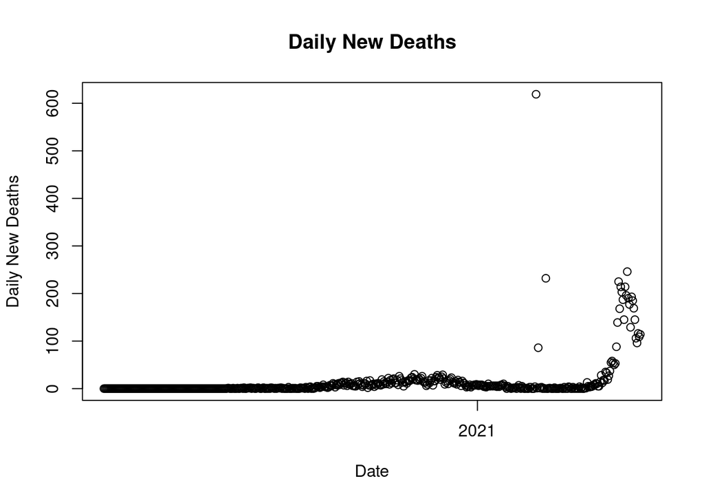

```r
#Plot
plot(covid_table$date2, covid_table$Deaths_New,main = "Daily New Deaths",xlab = "Date",ylab = "Daily New Deaths")
```

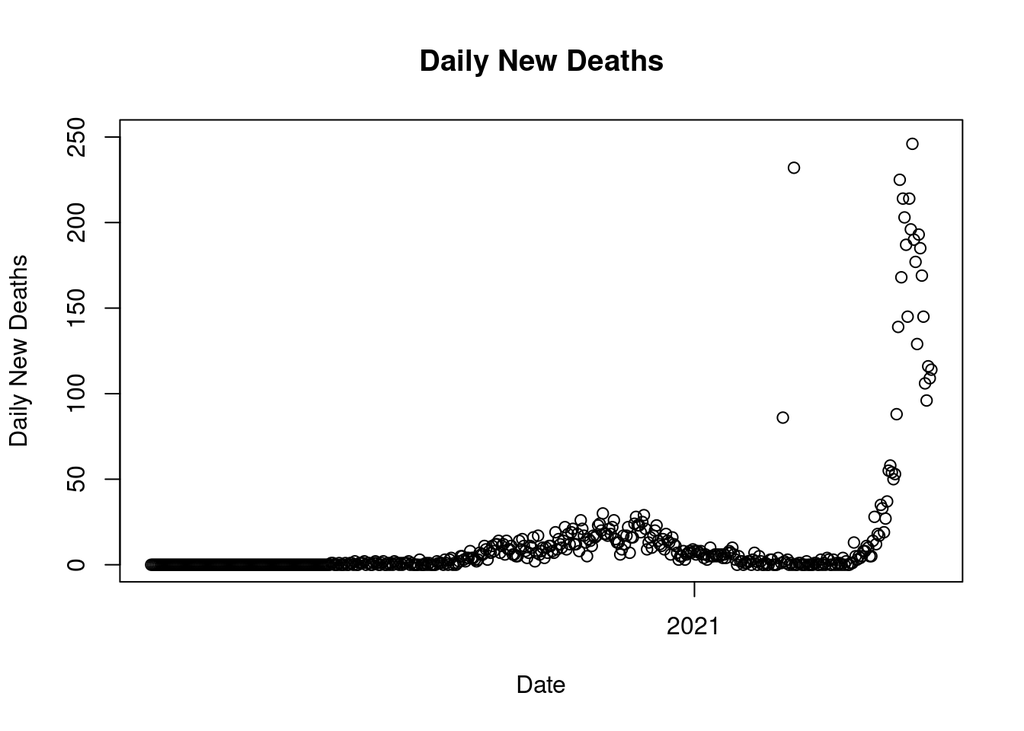

```r
plot(covid_table$date2, covid_table$Deaths_New, ylim =range(0:250),main = "Daily New Deaths",xlab = "Date",ylab = "Daily New Deaths")
```

As we can see in the first graph, there are three data points that are out of ordinary. For now we will replace these data points using data from other sources.

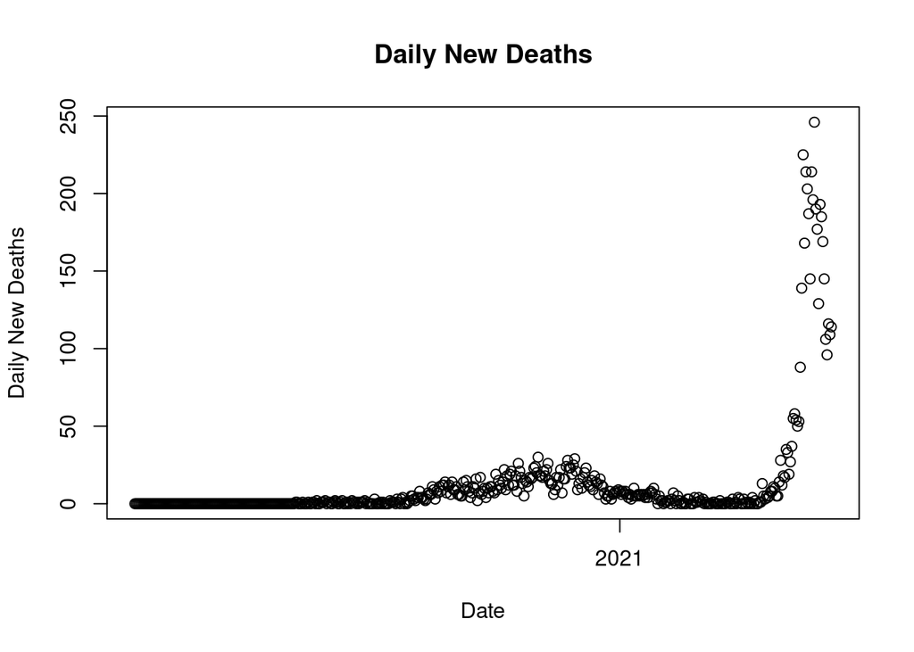

```r
#Repalce Deaths_New of 24 Feb as 1 in the data
covid_table[covid_table$date2=="2021-02-24", "Deaths_New"] = 1
covid_table[covid_table$date2=="2021-02-26", "Deaths_New"] = 4
covid_table[covid_table$date2=="2021-03-05", "Deaths_New"] = 0

plot(covid_table$date2, covid_table$Deaths_New, main = "Daily New Deaths",xlab = "Date",ylab = "Daily New Deaths")
```

```r
summary(covid_table$Deaths_New)
```

```
##    Min. 1st Qu.  Median    Mean 3rd Qu.    Max.
##    0.00    0.00    2.00   13.04   10.00  246.00
```

From summary above we can see that the maximum daily new deaths between 2020-01-23 and 2021-05-31 from covid in Nepal was 246. The mean median and the quartile values are low which means that the new deaths was relatively low for a long period of time and it exploded in the later time period.

```r
summary(covid_table$Deaths_Total)
```

```
##    Min. 1st Qu.  Median    Mean 3rd Qu.    Max.    NA's
##     0.0     0.0    18.0   142.9   149.0   984.0     210
```

The total number of deaths in Nepal was 984. However, this does not pain the accurate picture since the Deaths_Total column has null value from date 2020-11-02.

```r
summary(covid_table$Deaths_CFR)
```

```
## Length  Class   Mode
##      0   NULL   NULL
```

We got this result because we do not have column name Deaths_CFR. The correct column name is CFR.

```r
summary(covid_table$CFR)
```

```
##    Min. 1st Qu.  Median    Mean 3rd Qu.    Max.
##  0.0000  0.2200  0.5800  0.5216  0.7500  1.3200
```

This shows that the case fatality rate went up to 1.32%. This means that the at max 1.32% of total people who had covid died in Nepal from 2020-01-23 to 2021-05-31.

## Data Modeling

```r
#Simple Moving Average fit for new deaths data!
library(smooth)
sma = sma(covid_table$Deaths_New, h=14, silent=FALSE)
```

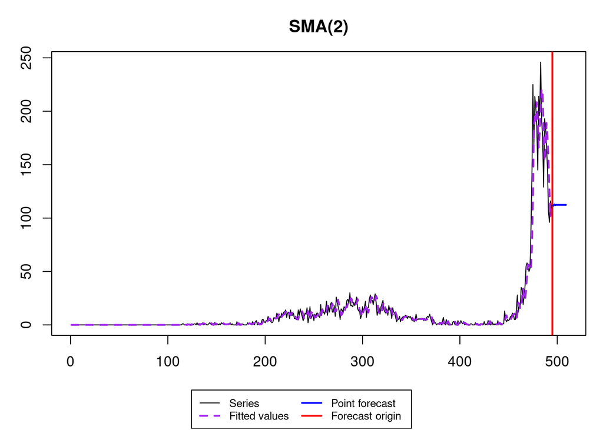

```r
summary(sma)
```

```
## Time elapsed: 4.96 seconds
## Model estimated: SMA(2)
## Initial values were produced using backcasting.
##
## Loss function type: MSE; Loss function value: 92.4722
## Error standard deviation: 9.6357
## Sample size: 495
## Number of estimated parameters: 2
## Number of degrees of freedom: 493
## Information criteria:
##      AIC     AICc      BIC     BICc
## 3649.569 3649.593 3657.978 3658.053
```

```r
forecast(sma)
```

```
## Time Series:
## Start = 496
## End = 505
## Frequency = 1
##     Point forecast Lower bound (2.5%) Upper bound (97.5%)
## 496       111.5000           92.56783            130.4322
## 497       112.7500           91.58319            133.9168
## 498       112.1250           86.63679            137.6132
## 499       112.4375           84.33662            140.5384
## 500       112.2812           81.31236            143.2501
## 501       112.3594           78.99122            145.7275
## 502       112.3203           76.60990            148.0307
## 503       112.3398           74.48099            150.1987
## 504       112.3301           72.41496            152.2452
## 505       112.3350           70.47560            154.1943
```

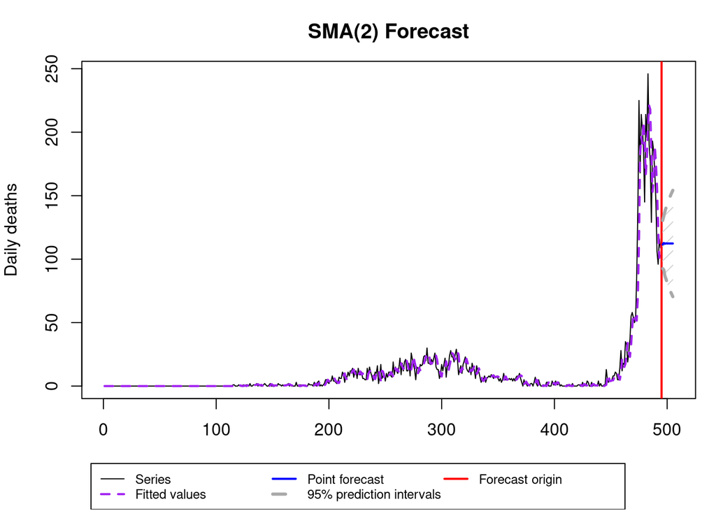

```r
plot(forecast(sma), main = "SMA(2) Forecast", ylab="Daily deaths")
```

## Importing Data From a Web API

```r
library(jsonlite)
url <- "https://data.askbhunte.com/api/v1/covid/timeline"
covidtbl <- fromJSON(txt=url, flatten=TRUE)
colnames(covidtbl)
```

```
## [1] "date"            "totalCases"      "newCases"        "totalRecoveries"
## [5] "newRecoveries"   "totalDeaths"     "newDeaths"
```

```r
summary(covidtbl)
```

```
##      date             totalCases       newCases    totalRecoveries
##  Length:247         Min.   :    0   Min.   :   0   Min.   :    0
##  Class :character   1st Qu.:    4   1st Qu.:   0   1st Qu.:    2
##  Mode  :character   Median : 1810   Median : 100   Median :  190
##                     Mean   :14277   Mean   : 315   Mean   : 9006
##                     3rd Qu.:20208   3rd Qu.: 466   3rd Qu.:14402
##                     Max.   :77816   Max.   :2020   Max.   :56282
##  newRecoveries     totalDeaths       newDeaths
##  Min.   :   0.0   Min.   :  0.00   Min.   : 0.000
##  1st Qu.:   0.0   1st Qu.:  0.00   1st Qu.: 0.000
##  Median :   4.0   Median :  8.00   Median : 0.000
##  Mean   : 227.9   Mean   : 72.06   Mean   : 2.016
##  3rd Qu.: 211.5   3rd Qu.: 59.00   3rd Qu.: 2.000
##  Max.   :2287.0   Max.   :498.00   Max.   :16.000
```